# Homework 1 - Question 2

## Dataset

```python
import os
import random

import torch
from sklearn.datasets import fetch_openml
from sklearn.model_selection import train_test_split
import time


def configure_seed(seed):
    os.environ["PYTHONHASHSEED"] = str(seed)
    random.seed(seed)
    np.random.seed(seed)
    torch.manual_seed(seed)
    if torch.cuda.is_available():
        torch.cuda.manual_seed(seed)
        torch.backends.cudnn.deterministic = True
        torch.backends.cudnn.benchmark = False


def fetch_classification_data(dataset="Fashion-MNIST", random_state=42):
    """
    Loads the dataset from openml, normalizes feature values (by dividing
    everything by 256), and saves to an npz file.

    dataset: the name of the dataset (accepted: "mnist_784", "Fashion-MNIST")
    """
    assert dataset in {"mnist_784", "Fashion-MNIST"}
    start_time = time.time()
    X, y = fetch_openml(dataset, version=1, return_X_y=True, as_frame=False)
    print("Downloaded data in {:.4f} seconds".format(time.time() - start_time))
    X /= 256  # normalize
    y = y.astype(int)  # fetch_openml loads it as a str
    train_dev_X, train_dev_y = X[:60000], y[:60000]
    train_X, dev_X, train_y, dev_y = train_test_split(
        train_dev_X, train_dev_y, train_size=50000, test_size=10000, random_state=random_state
    )
    test_X, test_y = X[60000:], y[60000:]
    np.savez_compressed(
        dataset + ".npz",
        Xtrain=train_X, ytrain=train_y,
        Xdev=dev_X, ydev=dev_y,
        Xtest=test_X, ytest=test_y
    )


def load_classification_data(bias=False):
    """
    Loads the preprocessed, featurized fashion-mnist dataset from
    Fashion-MNIST.npz, optionally adding a bias feature.
    """
    data = np.load('Fashion-MNIST.npz')
    train_X = data["Xtrain"]
    dev_X = data["Xdev"]
    test_X = data["Xtest"]
    if bias:
        train_X = np.hstack((train_X, np.ones((train_X.shape[0], 1))))
        dev_X = np.hstack((dev_X, np.ones((dev_X.shape[0], 1))))
        test_X = np.hstack((test_X, np.ones((test_X.shape[0], 1))))
    return {"train": (train_X, data["ytrain"]),
            "dev": (dev_X, data["ydev"]),
            "test": (test_X, data["ytest"])}


def load_regression_data(bias=False):
    """
    Loads the preprocessed, featurized Ames housing dataset from ames.npz.
    """
    data = np.load('ames.npz')
    train_X = data["Xtrain"]
    test_X = data["Xtest"]
    train_y = data["ytrain"].reshape(-1)
    test_y = data["ytest"].reshape(-1)
    if bias:
        train_X = np.hstack((train_X, np.ones((train_X.shape[0], 1))))
        test_X = np.hstack((test_X, np.ones((test_X.shape[0], 1))))
    return {"train": (train_X, train_y),
            "test": (test_X, test_y)}


class ClassificationDataset(torch.utils.data.Dataset):

    def __init__(self, data):
        """
        data: the dict returned by utils.load_classification_data
        """
        train_X, train_y = data["train"]
        dev_X, dev_y = data["dev"]
        test_X, test_y = data["test"]

        self.X = torch.tensor(train_X, dtype=torch.float32)
        self.y = torch.tensor(train_y, dtype=torch.long)

        self.dev_X = torch.tensor(dev_X, dtype=torch.float32)
        self.dev_y = torch.tensor(dev_y, dtype=torch.long)

        self.test_X = torch.tensor(test_X, dtype=torch.float32)
        self.test_y = torch.tensor(test_y, dtype=torch.long)

    def __len__(self):
        return len(self.X)

    def __getitem__(self, idx):
        return self.X[idx], self.y[idx]
```

## (a)

Implement the update_weights method of the `LinearRegression` class in hw1-q2.py. Train the model for `150 epochs` using stochastic gradient descent with a `learning rate of 0.001`. Report the performance on the training and test set. Plot the accuracy on both sets as a function of the epoch number. Explain the observed difference between the performance on the training and test sets as the number of epochs increases. Also report the distance between your weight vector and the weight vector computed analytically as a function of the epoch number (you will need to compute the analytic solution yourself by implementing the `solve_analytically` function).

```python
import argparse

import numpy as np
import matplotlib.pyplot as plt

import utils
```

```python
def distance(analytic_solution, model_params):
    return np.linalg.norm(analytic_solution - model_params)
```

```python
def solve_analytically(X, y):
    """
    X (n_points x n_features)
    y (vector of size n_points)

    Q2.1: given X and y, compute the exact, analytic linear regression solution.
    This function should return a vector of size n_features (the same size as
    the weight vector in the LinearRegression class).
    """
    # X has bias term in the last column

    # Compute the weights (last weight corresponds to bias term):
    # Using pseudo inverse because np.linalg.inv did not work because matrix was singular
    W = np.linalg.pinv(X.transpose().dot(X)).dot(X.transpose()).dot(y) # (n_features,)

    return W
```

```python
class _RegressionModel:
    """
    Base class that allows evaluation code to be shared between the
    LinearRegression and NeuralRegression classes. You should not need to alter
    this class!
    """
    def train_epoch(self, X, y, **kwargs):
        """
        Iterate over (x, y) pairs, compute the weight update for each of them.
        Keyword arguments are passed to update_weight
        """
        for x_i, y_i in zip(X, y):
            # x_i: row of train_X (n_features,)
            # y_i: value of y for example x_i
            self.update_weight(x_i, y_i, **kwargs)

    def evaluate(self, X, y):
        """
        return the mean squared error between the model's predictions for X
        and the ground truth y values
        """
        yhat = self.predict(X) # (n_features, )
        error = yhat - y # (n_features, )
        squared_error = np.dot(error, error) # number
        mean_squared_error = squared_error / y.shape[0]
        return np.sqrt(mean_squared_error)
```

```python
class LinearRegression(_RegressionModel):
    def __init__(self, n_features, **kwargs):
        self.w = np.zeros((n_features)) # (n_features,)

    def update_weight(self, x_i, y_i, learning_rate=0.001):
        """
        Q2.2a

        x_i, y_i: a single training example

        This function makes an update to the model weights (in other words,
        self.w).
        """
        # gradient of mean squared error loss dL/dy_hat = 2*(y_hat-y)
        grad_loss = 2*(self.predict(x_i) - y_i) # number
        # gradient of y_hat with respect to the parametes d(y_hat)/dw = x_i
        self.w = self.w - learning_rate * (np.dot(grad_loss, x_i))
        return self.w # (n_features,)

    def predict(self, X):
        return np.dot(X, self.w)
```

```python
def plot(epochs, train_loss, test_loss):
    plt.xlabel('Epoch')
    plt.ylabel('Loss')
    plt.xticks(np.arange(0, epochs[-1] + 1, step=10))
    plt.plot(epochs, train_loss, label='train')
    plt.plot(epochs, test_loss, label='test')
    plt.legend()
    plt.show()
```

```python
def plot_dist_from_analytic(epochs, dist):
    plt.xlabel('Epoch')
    plt.ylabel('Dist')
    plt.xticks(np.arange(0, epochs[-1] + 1, step=10))
    plt.plot(epochs, dist, label='dist')
    plt.legend()
    plt.show()
```

```python
def main(model = 'linear_regression', n_epochs = 150, hidden_size = 150, learning_rate = 0.001):

    configure_seed(seed=42)

    add_bias = model != 'nn'
    data = load_regression_data(bias=add_bias)
    train_X, train_y = data["train"]
    test_X, test_y = data["test"]

    n_points, n_feats = train_X.shape

    # Linear regression has an exact, analytic solution. Implement it in
    # the solve_analytically function defined above.
    if model == "linear_regression":
        analytic_solution = solve_analytically(train_X, train_y)
    else:
        analytic_solution = None

    # initialize the model
    if model == "linear_regression":
        model = LinearRegression(n_feats)
    else:
        model = NeuralRegression(n_feats, hidden_size)

    # training loop
    epochs = np.arange(1, n_epochs + 1)
    train_losses = []
    test_losses = []
    dist_opt = []
    for epoch in epochs:
        print('Epoch %i... ' % epoch)
        train_order = np.random.permutation(train_X.shape[0])
        train_X = train_X[train_order]
        train_y = train_y[train_order]
        model.train_epoch(train_X, train_y, learning_rate=learning_rate)

        # Evaluate on the train and test data.
        train_losses.append(model.evaluate(train_X, train_y))
        test_losses.append(model.evaluate(test_X, test_y))

        if analytic_solution is not None:
            model_params = model.w
            dist_opt.append(distance(analytic_solution, model_params))

        print('Loss (train): %.3f | Loss (test): %.3f' % (train_losses[-1], test_losses[-1]))

    plot(epochs, train_losses, test_losses)

    if analytic_solution is not None:
        plot_dist_from_analytic(epochs, dist_opt)
```

```
Epoch 1...
Loss (train): 0.439 | Loss (test): 0.573
Epoch 2...
Loss (train): 0.344 | Loss (test): 0.468
Epoch 3...
Loss (train): 0.286 | Loss (test): 0.350
Epoch 4...
Loss (train): 0.262 | Loss (test): 0.334
Epoch 5...
Loss (train): 0.237 | Loss (test): 0.301
Epoch 6...
Loss (train): 0.217 | Loss (test): 0.275
Epoch 7...
Loss (train): 0.212 | Loss (test): 0.264
Epoch 8...
Loss (train): 0.193 | Loss (test): 0.248
Epoch 9...
Loss (train): 0.186 | Loss (test): 0.245
Epoch 10...
Loss (train): 0.193 | Loss (test): 0.243
Epoch 11...
Loss (train): 0.195 | Loss (test): 0.243
Epoch 12...
Loss (train): 0.169 | Loss (test): 0.226
Epoch 13...
Loss (train): 0.166 | Loss (test): 0.219
Epoch 14...
Loss (train): 0.168 | Loss (test): 0.227
Epoch 15...
Loss (train): 0.157 | Loss (test): 0.215
Epoch 16...
Loss (train): 0.164 | Loss (test): 0.220
Epoch 17...
Loss (train): 0.153 | Loss (test): 0.207
Epoch 18...
Loss (train): 0.155 | Loss (test): 0.209
Epoch 19...
Loss (train): 0.148 | Loss (test): 0.205
Epoch 20...
Loss (train): 0.148 | Loss (test): 0.209
```

[output cut: 245 more lines]

```
Loss (train): 0.110 | Loss (test): 0.286
Epoch 144...
Loss (train): 0.112 | Loss (test): 0.288
Epoch 145...
Loss (train): 0.104 | Loss (test): 0.293
Epoch 146...
Loss (train): 0.106 | Loss (test): 0.288
Epoch 147...
Loss (train): 0.106 | Loss (test): 0.292
Epoch 148...
Loss (train): 0.103 | Loss (test): 0.290
Epoch 149...
Loss (train): 0.106 | Loss (test): 0.283
Epoch 150...
Loss (train): 0.103 | Loss (test): 0.288
```

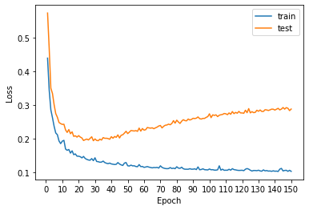

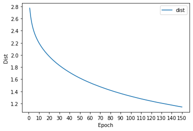

```python
main(model = 'linear_regression', n_epochs = 150, hidden_size = 150, learning_rate = 0.001)
```

## (b)

You will now train a neural network model for the same regression problem. **Without using any neural network toolkit**, implement a feed-forward network with a single hidden layer to solve the regression problem above, including the gradient back-propagation algorithm which is needed to train the model. You can achieve this by implementing the `__init__()`, `update_weight`, and `predict` methods of the provided `NeuralRegression` class. Use `150 hidden units`, a `ReLU activation function` for the hidden layer, and a `mean squared error loss` in the output. Train the model with stochastic gradient descent with a `learning rate of 0.001` for `150 epochs`. Initialize biases with zero vectors and values in weight matrices with $wij ∼ N(µ, σ^2)$ with $µ = 0.1$ and $σ^2 = 0.1^2$ (hint: use numpy.random.normal). Report the performance on the training and test set. Plot the accuracy in both sets as a function of the epoch number. Compare the observed difference between the performance in the training and test sets with that observed in the linear model.

```python
import argparse

import numpy as np
import matplotlib.pyplot as plt

import utils
```

```python
class _RegressionModel:
    """
    Base class that allows evaluation code to be shared between the
    LinearRegression and NeuralRegression classes. You should not need to alter
    this class!
    """
    def train_epoch(self, X, y, **kwargs):
        """
        Iterate over (x, y) pairs, compute the weight update for each of them.
        Keyword arguments are passed to update_weight
        """
        for x_i, y_i in zip(X, y):
            # x_i: row of train_X (n_features,)
            # y_i: value of y for example x_i
            self.update_weight(x_i, y_i, **kwargs)

    def evaluate(self, X, y):
        """
        return the mean squared error between the model's predictions for X
        and the ground truth y values
        """
        yhat = self.predict(X) # (n_features, )
        error = yhat - y # (n_features, )
        squared_error = np.dot(error, error) # number
        mean_squared_error = squared_error / y.shape[0]
        return np.sqrt(mean_squared_error)
```

```python
class NeuralRegression(_RegressionModel):
    """
    Q2.2b
    """
    def __init__(self, n_features, hidden):
        """
        In this __init__, you should define the weights of the neural
        regression model (for example, there will probably be one weight
        matrix per layer of the model).
        """

        # initialize weight matrices with mu = 0.1 and std = 0.1
        self.weights = [np.random.normal(0.1, 0.1, size = (n_features, hidden)),
                        np.random.normal(0.1, 0.1, size = (hidden, 1))]
        # initialize bias vectors
        self.biases = [np.zeros(hidden),
                       np.zeros(1)]

    def update_weight(self, x_i, y_i, learning_rate=0.001):
        """
        x_i, y_i: a single training example

        This function makes an update to the model weights
        """
        # forward pass
        num_layers = len(self.weights)
        hiddens = []
        for i in range(num_layers):
            h = x_i if i == 0 else hiddens[i-1]
            z = np.dot(h, self.weights[i]) + self.biases[i]
            if i < num_layers-1:
                hiddens.append(np.maximum(z,0))
        yhat = z

        # backward pass
        grad_z = 2*(yhat - y_i) # gradient dL/dz
        grad_weights = []
        grad_biases = []

        for i in range(num_layers - 1, -1, -1):

            h = x_i if i == 0 else hiddens[i-1]
            # compute gradient of parameters:
            grad_weights.append(np.dot(h[:,None], grad_z[:,None].T))
            grad_biases.append(grad_z)

            # compute gradient of hidden layer after activation function:
            grad_h = np.dot(grad_z, self.weights[i].T)

            # compute gradient of hidden layer before activation:
            grad_z = grad_h * (h > 0) # (h > 0) to get the gradient of the ReLU

        grad_weights.reverse()
        grad_biases.reverse()

        # updating the weights
        for i in range(num_layers):
            self.weights[i] -= learning_rate * grad_weights[i]
            self.biases[i] -= learning_rate * grad_biases[i]

        return self.weights, self.biases

    def predict(self, X):
        """
        X: a (n_points x n_feats) matrix.

        This function runs the forward pass of the model, returning yhat, a
        vector of size n_points that contains the predicted values for X.

        This function will be called by evaluate(), which is called at the end
        of each epoch in the training loop. It should not be used by
        update_weight because it returns only the final output of the network,
        not any of the intermediate values needed to do backpropagation.
        """

        # forward pass
        num_layers = len(self.weights)
        hiddens = []
        for i in range(num_layers):
            h = X if i == 0 else hiddens[i-1]
            z = np.dot(h, self.weights[i]) + self.biases[i]
            if i < num_layers-1:
                hiddens.append(np.maximum(z,0))
        # z (n_points, 1) so we remove last dimension to work with evaluate
        yhat = z.reshape(-1,)
        return yhat
```

```python
def plot(epochs, train_loss, test_loss):
    plt.xlabel('Epoch')
    plt.ylabel('Loss')
    plt.xticks(np.arange(0, epochs[-1] + 1, step=10))
    plt.plot(epochs, train_loss, label='train')
    plt.plot(epochs, test_loss, label='test')
    plt.legend()
    plt.show()
```

```python
def plot_dist_from_analytic(epochs, dist):
    plt.xlabel('Epoch')
    plt.ylabel('Dist')
    plt.xticks(np.arange(0, epochs[-1] + 1, step=10))
    plt.plot(epochs, dist, label='dist')
    plt.legend()
    plt.show()
```

```python
def main(model = 'linear_regression', n_epochs = 150, hidden_size = 150, learning_rate = 0.001):

    configure_seed(seed=42)

    add_bias = model != 'nn'
    data = load_regression_data(bias=add_bias)
    train_X, train_y = data["train"]
    test_X, test_y = data["test"]

    n_points, n_feats = train_X.shape

    # Linear regression has an exact, analytic solution. Implement it in
    # the solve_analytically function defined above.
    if model == "linear_regression":
        analytic_solution = solve_analytically(train_X, train_y)
    else:
        analytic_solution = None

    # initialize the model
    if model == "linear_regression":
        model = LinearRegression(n_feats)
    else:
        model = NeuralRegression(n_feats, hidden_size)

    # training loop
    epochs = np.arange(1, n_epochs + 1)
    train_losses = []
    test_losses = []
    dist_opt = []
    for epoch in epochs:
        print('Epoch %i... ' % epoch)
        train_order = np.random.permutation(train_X.shape[0])
        train_X = train_X[train_order]
        train_y = train_y[train_order]
        model.train_epoch(train_X, train_y, learning_rate=learning_rate)

        # Evaluate on the train and test data.
        train_losses.append(model.evaluate(train_X, train_y))
        test_losses.append(model.evaluate(test_X, test_y))

        if analytic_solution is not None:
            model_params = model.w
            dist_opt.append(distance(analytic_solution, model_params))

        print('Loss (train): %.3f | Loss (test): %.3f' % (train_losses[-1], test_losses[-1]))

    plot(epochs, train_losses, test_losses)

    if analytic_solution is not None:
        plot_dist_from_analytic(epochs, dist_opt)
```

```
Epoch 1...
Loss (train): 1.531 | Loss (test): 3.968
Epoch 2...
Loss (train): 0.867 | Loss (test): 3.625
Epoch 3...
Loss (train): 0.630 | Loss (test): 3.561
Epoch 4...
Loss (train): 0.501 | Loss (test): 3.524
Epoch 5...
Loss (train): 0.456 | Loss (test): 3.511
Epoch 6...
Loss (train): 0.396 | Loss (test): 3.502
Epoch 7...
Loss (train): 0.353 | Loss (test): 3.502
Epoch 8...
Loss (train): 0.322 | Loss (test): 3.492
Epoch 9...
Loss (train): 0.319 | Loss (test): 3.498
Epoch 10...
Loss (train): 0.288 | Loss (test): 3.492
Epoch 11...
Loss (train): 0.375 | Loss (test): 3.510
Epoch 12...
Loss (train): 0.295 | Loss (test): 3.478
Epoch 13...
Loss (train): 0.257 | Loss (test): 3.478
Epoch 14...
Loss (train): 0.242 | Loss (test): 3.485
Epoch 15...
Loss (train): 0.400 | Loss (test): 3.516
Epoch 16...
Loss (train): 0.264 | Loss (test): 3.492
Epoch 17...
Loss (train): 0.246 | Loss (test): 3.473
Epoch 18...
Loss (train): 0.226 | Loss (test): 3.485
Epoch 19...
Loss (train): 0.203 | Loss (test): 3.477
Epoch 20...
Loss (train): 0.235 | Loss (test): 3.471
```

[output cut: 245 more lines]

```
Loss (train): 0.128 | Loss (test): 3.477
Epoch 144...
Loss (train): 0.123 | Loss (test): 3.480
Epoch 145...
Loss (train): 0.138 | Loss (test): 3.488
Epoch 146...
Loss (train): 0.141 | Loss (test): 3.489
Epoch 147...
Loss (train): 0.152 | Loss (test): 3.473
Epoch 148...
Loss (train): 0.126 | Loss (test): 3.485
Epoch 149...
Loss (train): 0.128 | Loss (test): 3.477
Epoch 150...
Loss (train): 0.139 | Loss (test): 3.489
```

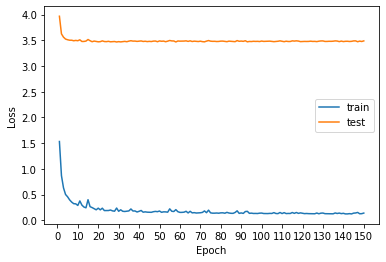

```python
main(model = 'nn', n_epochs = 150, hidden_size = 150, learning_rate = 0.001)
```